# Исследование данных о компьютерных играх для интернет-магазина

## Портрет пользователя каждого региона

Функция для визуализации наиболее популярных платфором и жанров, а также соотношения игр с разными рейтингами для пользователей определённого региона.

```python
#написание функции
def user_description(df, col_reg, region):
    try:
        #сводная таблица продаж по платформам в регионе
        pivot_plat = (df
                      .pivot_table(
                          index='platform',
                          values=col_reg,
                          aggfunc='sum')
                      .sort_values(by=col_reg, ascending=False)
                     )

        #таблица для диаграммы (платформы)
        plat = (pivot_plat
                .head()
                .append(pd.DataFrame(
                    data={col_reg:[pivot_plat
                      .sort_values(by=col_reg, ascending=False)
                            [-(len(pivot_plat.index)-5):][col_reg].sum()]},
                    index=['Остальные']))
               )

        #диаграмма долей продаж по платформам
        plat.plot(
            kind='pie',
            y=col_reg,
            title=f'Доли продаж различных платформ для региона {region}',
            label='',
            autopct='%0.1f%%',
            colors=colors,
            figsize=(5,5),
            legend=False)

        #график топ-5 платформ
        plt.figure(figsize=(14,2))
        plt.barh(
            (plat
                .head()
                .sort_values(by=col_reg)
                .index
            ),
            (plat
                .head()
                .sort_values(by=col_reg)
                [col_reg]
            )

        );
        plt.grid(True)
        plt.ylabel('Платформы')
        plt.xlabel('Продажи, млн')
        plt.title(f'Топ-5 популярных платформ для региона {region}')
        plt.show()


        #сводная таблица продаж по жанрам в регионе
        pivot_genres = (df
                      .pivot_table(
                          index='genre',
                          values=col_reg,
                          aggfunc='sum')
                      .sort_values(by=col_reg, ascending=False)
                     )


        #таблица для диаграммы (жанры)
        genres = (pivot_genres
                .head()
                .append(pd.DataFrame(
                    data={col_reg:[pivot_genres
                      .sort_values(by=col_reg, ascending=False)
                            [-(len(pivot_genres.index)-5):][col_reg].sum()]},
                    index=['Остальные']))
               )

        #диаграмма долей продаж по жанрам
        genres.plot(
            kind='pie',
            y=col_reg,
            title=f'Доли продаж игр различных жанров для региона {region}',
            label='',
            autopct='%0.1f%%',
            colors=colors,
            figsize=(5,5),
            legend=False)

        #график топ-5 жанров
        plt.figure(figsize=(14,2))
        plt.barh(
            (genres
                .head()
                .sort_values(by=col_reg)
                .index
            ),
            (genres
                .head()
                .sort_values(by=col_reg)
                [col_reg]
            )

        );
        plt.grid(True)
        plt.ylabel('Жанры')
        plt.xlabel('Продажи, млн')
        plt.title(f'Топ-5 популярных жанров для региона {region}')
        plt.show()

        #сводная таблица продаж по рейтингам в регионе
        pivot_rating = (df
                      .pivot_table(
                          index='rating',
                          values=col_reg,
                          aggfunc='sum')
                      .sort_values(by=col_reg, ascending=False)
                     )

        #диаграмма: доли продаж игр разных рейтингов
        pivot_rating.plot(
            kind='pie',
            y=col_reg,
            title=f'Доли продаж игр различных рейтингов для региона {region}',
            label='',
            autopct='%0.1f%%',
            colors=colors,
            figsize=(5,5),
            legend=False)

    except:
        return('Ошибка работы функции user_description')
```

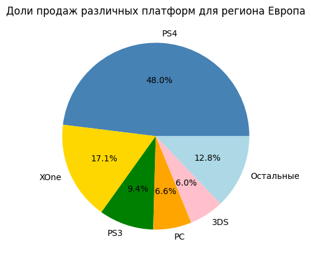

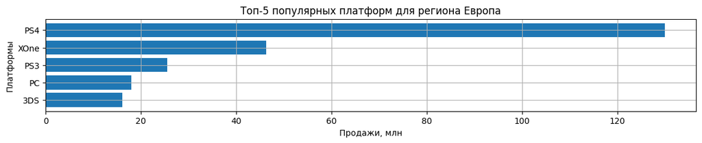

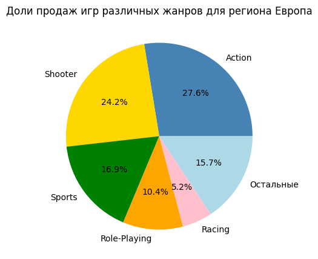

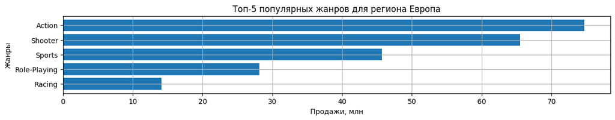

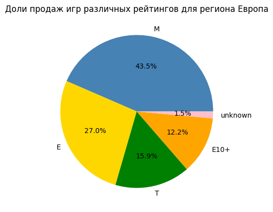

```python
#портрет пользователя региона EU
user_description(data_act, 'eu_sales', 'Европа')
```

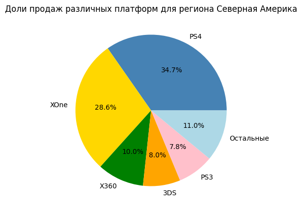

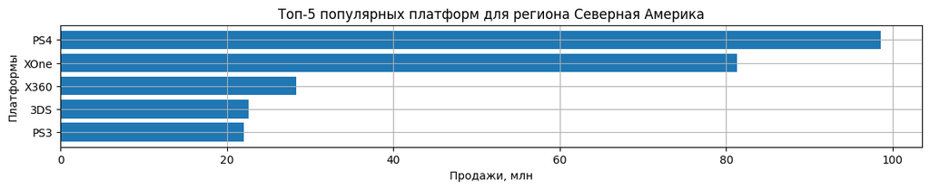

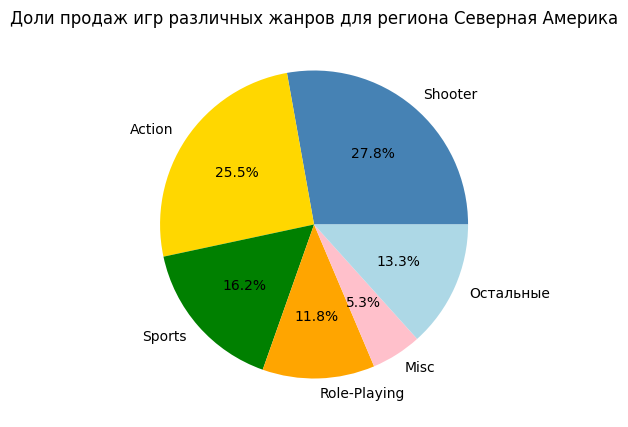

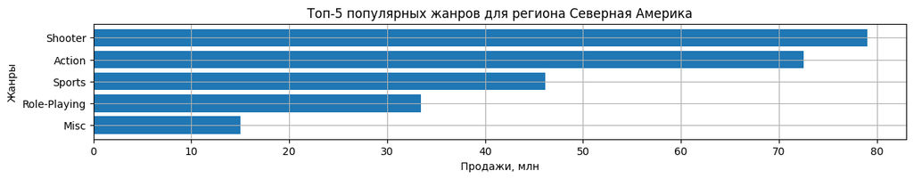

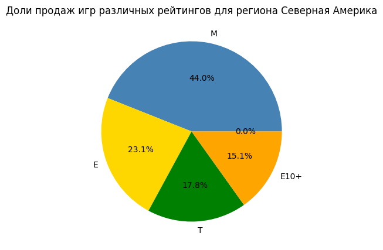

```python
#портрет пользователя региона NA
user_description(data_act, 'na_sales', 'Северная Америка')
```

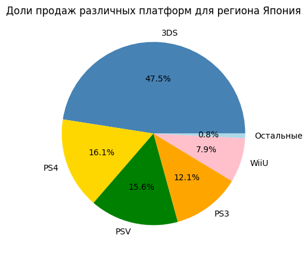

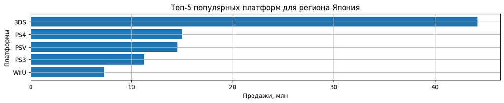

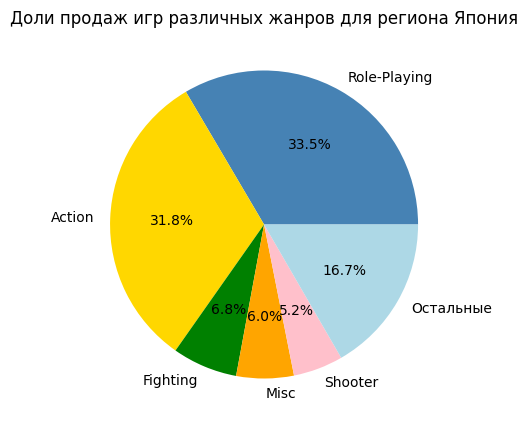

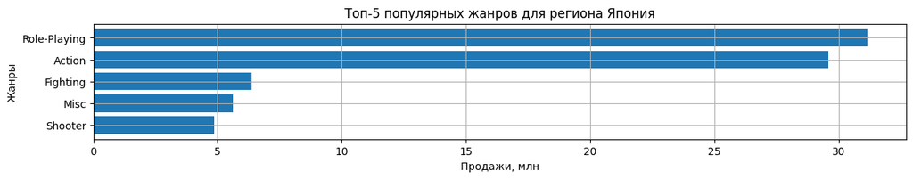

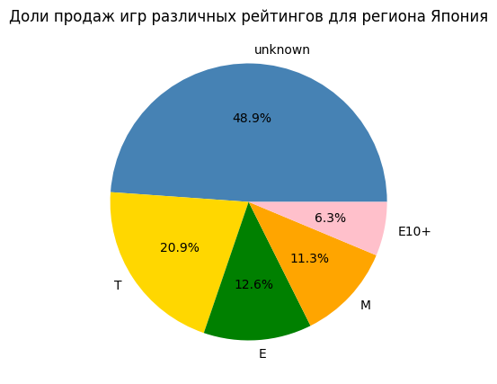

```python
#портрет пользователя региона JP
user_description(data_act, 'jp_sales', 'Япония')
```

### Наиболее популярные платформы в различных регионах

#### Северная Америка:

- **PS4** 34,7%
- **XOne** 28,6%
- **X360** 10%
- **3DS** 8%
- **PS3** 7,8%

#### Япония

- **3DS** 47,5%
- **PS4** 16,1%
- **PSV** 15,6%
- **PS3** 12,1%
- **WiiU** 7,9%

В Японии же платформа **3DS**, не пользующаяся большой популярностью в Европе и Северной Америке, лидирует с большим отрывом, также в топ-5 здесь попадают **WiiU** и **PSV**, которые в других регионах не демонстрируют заметных продаж.

### Наиболее популярные жанры в различных регионах

#### Европа:

- **Action** 27,6%
- **Shooter** 24,2%
- **Sports** 16,9%
- **Role-Playing** 10,4%
- **Racing** 5,2%

#### Северная Америка:

- **Shooter** 27,8%
- **Action** 25,5%
- **Sports** 16,2%
- **Role-Playing** 11,8%
- **Misc** 5,3%

#### Япония

- **Role-Playing** 33,5%
- **Action** 31,8%
- **Fighting** 6,8%
- **Misc** 6%
- **Shooter** 5,2%

Набор пяти наиболее популярных жанров в Северной Америке и Европе очень похож. С большим отрывом лидируют игры в жнрах **Action** и **Shooter**, в обоих регионах они занимают более половины рынка.

В Японии картина совершенно другая: игры в жанре **Action** занимают второе место, на первом игры в жанре **Role-Playing**.

### Влияние рейтинга на продажи в регионах

#### Европа:

- **M** 43,5%
- **E** 27%
- **T** 15,9%
- **E10+** 12,2%

#### Северная Америка:

- **M** 44%
- **E** 23,1%
- **T** 17,8%
- **E10+** 15,1%

#### Япония

- **Игры, не промаркированные агентством ESRB** 48,9%
- **T** 20,9%
- **E** 12,6%
- **M** 11,3%
- **E10+** 6,3%

В Японии почти половина всех продаж приходится на игры, не имеющие маркировки возрастных ограничений ESRB, из промаркированных игр наибольшую выручку приносят игры для детей и подростков, доля продаж игр для взрослых здесь намного ниже, чем в двух других регионах.

## Проверка гипотез

### Средние пользовательские рейтинги платформ Xbox One и PC одинаковые.

Формулирование гипотез.

В нашем распоряжении две генеральные совокупности, которые можно считать независимыми.

Нулевая гипотеза: средний пользовательский рейтинг платформы **XOne** равен среднему пользовательскому рейтингу платформы **PC**.

Альтернативная гипотеза: средний пользовательский рейтинг платформы **XOne** не равен среднему пользовательскому рейтингу платформы **PC**.

Гипотеза двустороняя.

Проверка гипотез.

```python
#уровень статистической значимости
alpha = 0.05

#расчёт и вывод p-value
results = st.ttest_ind(
    data_user.query('platform == "XOne"')['user_score'],
    data_user.query('platform == "PC"')['user_score']
)

print('p-значение:', results.pvalue, '\n')

#результат
if results.pvalue < alpha:
    print('Отвергаем нулевую гипотезу')
else:
    print('Не получилось отвергнуть нулевую гипотезу')

print(
    '\n'
    'Cредний пользовательский рейтинг платформы "XOne": ', round(
        data_user
        .query('platform == "XOne"')['user_score']
        .mean(),
        2),
    '\n',
    '\n',
    'Cредний пользовательский рейтинг платформы "PC": ', round(
        data_user
        .query('platform == "PC"')['user_score']
        .mean(),
        2),
)
```

```
p-значение: 0.10450507919348415

Не получилось отвергнуть нулевую гипотезу

Cредний пользовательский рейтинг платформы "XOne":  6.59

 Cредний пользовательский рейтинг платформы "PC":  6.3
```

Несмотря на то, что мы можем вычислить средние рейтинги для обеих платформ (они не равны), параметры имеющихся выборок таковы, что по результатам статистического теста при заданном уровне статистической значимости нельзя отвергнуть нулевую гипотезу и уверенно утверждать, что они не равны.

Вероятно, в данном случае уровень статистической значимости для получения достоверного результата нужно увеличить до 11% по меньшей мере.

### Средние пользовательские рейтинги жанров Action и Sports одинаковые.

Формулирование гипотез.

В нашем распоряжении две генеральные совокупности, которые можно считать независимыми.

Нулевая гипотеза: средний пользовательский рейтинг жанра **Action** равен среднему пользовательскому рейтингу жанра **Sports**.

Альтернативная гипотеза: средний пользовательский рейтинг жанра **Action** не равен среднему пользовательскому рейтингу жанра **Sports**.

Гипотеза двустороняя.

Проверка гипотез.

```python
#уровень статистической значимости
alpha = 0.05

#расчёт и вывод p-value
results = st.ttest_ind(
    data_user.query('genre == "Action"')['user_score'],
    data_user.query('genre == "Sports"')['user_score']
)

print('p-значение:', results.pvalue, '\n')

#результат
if results.pvalue < alpha:
    print('Отвергаем нулевую гипотезу')
else:
    print('Не получилось отвергнуть нулевую гипотезу')

print(
    '\n'
    'Cредний пользовательский рейтинг платформы "XOne": ', round(
        data_user
        .query('genre == "Action"')['user_score']
        .mean(),
        2),
    '\n',
    '\n',
    'Cредний пользовательский рейтинг платформы "PC": ', round(
        data_user
        .query('genre == "Sports"')['user_score']
        .mean(),
        2),
)
```

```
p-значение: 2.8711147985105864e-19

Отвергаем нулевую гипотезу

Cредний пользовательский рейтинг платформы "XOne":  6.76

 Cредний пользовательский рейтинг платформы "PC":  5.23
```

Есть основания полагать, что средний пользовательский рейтинг жанра **Action** не равен среднему пользовательскому рейтингу жанра **Sports**.

## Общий вывод

### Результаты общего исследования данных

С 1980 по 1992 годы выпускали скромное по современным меркам количество игр. В начале 1980-х был небольшой бум выпуска игр, который сошёл на нет к 1990 году. Начиная с 1991 года наблюдается рост количествоа выпущенных игр, который с небольшими перерывами в 1999-2000 и 2002-2003 годах продолжался до максимума в 2008-2009 годах, а затем пошёл на спад, вероятно, сказался мировой экономический кризис 2008 года. Начиная с 2012 года количество выпущенных игр распределено сравнительно равномерно.

За весь наблюдаемый период 1980-2016 гг. можно выделить шесть наиболее популярных платформ:

- **PS2**
- **X360**
- **PS3**
- **Wii**
- **DS**
- **PS**

Наиболее актуальным и подходящим для анализа выглядит период 2014-2016 годов, поскольку это наиболее близкий к 2017 году период с относительно стабильной тенденцией количества выпущенных игр.

За выбранный период (2014-2016 годы) есть данные о 10 платформах. Наибольшие продажи демонстрируют 5 из них:

- **PS4**
- **XOne**
- **3DS**
- **PS3**
- **X360**

Платформа **PS4** лидирует с большим отрывом.

По объёмам продаж лидируют следующие платформы:

- **PS4**
- **XOne**
- **3DS**

Ни одна из платформ не демонстрирует роста продаж.

Для каждой из рассматриваемых платформ есть относительно небольшое количество популярных игр и гораздо большая основная масса игр, притом суммарные продажи немногочисленных игр-лидеров сравнимы и могут даже превышать суммарные продажи большинства менее популярных игр.

Разброс глобальных продаж разнится для разных платформ: для одних (**PS3**, **X360** и другие) выпущены настоящие хиты, далеко обогнавшие ближайших конкурентов, у других разница в продажах между самыми популярными играми и основным количеством игр небольшая.

Взаимосвязь глобальных продаж остальных игр с отзывами критиков и пользователей почти такая же, как и для игр, выпущенных на самой популярной платформе **"PS4"**: корелляция с отзывами критиков и пользователей слабая, для многих платформ почти нулевая.

Из шести наиболее популярных с точки зрения суммарных и медианных продаж самый прибыльный и при этом надёжный - **Shooter**: судя по диаграмме размаха, среди игр этого жанра меньше хитов, при этом игры с меньшими, чем у хитов, объёмами выручки распределены более равномерно, чем у других жанров. Это означает, что игры этого жанра стабильнее, чем игры других жанров, демонстрируют относительно высокие продажи.

### Портрет пользователя каждого региона

#### Наиболее популярные платформы в различных регионах

##### Северная Америка:

- **PS4** 34,7%
- **XOne** 28,6%
- **X360** 10%
- **3DS** 8%
- **PS3** 7,8%

##### Япония

- **3DS** 47,5%
- **PS4** 16,1%
- **PSV** 15,6%
- **PS3** 12,1%
- **WiiU** 7,9%

В Японии же платформа **3DS**, не пользующаяся большой популярностью в Европе и Северной Америке, лидирует с большим отрывом, также в топ-5 здесь попадают **WiiU** и **PSV**, которые в других регионах не демонстрируют заметных продаж.

#### Наиболее популярные жанры в различных регионах

##### Европа:

- **Action** 27,6%
- **Shooter** 24,2%
- **Sports** 16,9%
- **Role-Playing** 10,4%
- **Racing** 5,2%

##### Северная Америка:

- **Shooter** 27,8%
- **Action** 25,5%
- **Sports** 16,2%
- **Role-Playing** 11,8%
- **Misc** 5,3%

##### Япония

- **Role-Playing** 33,5%
- **Action** 31,8%
- **Fighting** 6,8%
- **Misc** 6%
- **Shooter** 5,2%

Набор пяти наиболее популярных жанров в Северной Америке и Европе очень похож. С большим отрывом лидируют игры в жанрах **Action** и **Shooter**, в обоих регионах они занимают более половины рынка.

В Японии картина совершенно другая: игры в жанре **Action** занимают второе место, на первом игры в жанре **Role-Playing**.

#### Влияние рейтинга на продажи в регионах

##### Европа:

- **M** 43,5%
- **E** 27%
- **T** 15,9%
- **E10+** 12,2%

##### Северная Америка:

- **M** 44%
- **E** 23,1%
- **T** 17,8%
- **E10+** 15,1%

##### Япония

- **Игры, не промаркированные агентством ESRB** 48,9%
- **T** 20,9%
- **E** 12,6%
- **M** 11,3%
- **E10+** 6,3%

В Японии почти половина всех продаж приходится на игры, не имеющие маркировки возрастных ограничений ESRB, из промаркированных игр наибольшую выручку приносят игры для детей и подростков, доля продаж игр для взрослых здесь намного ниже, чем в двух других регионах.

### Рекомендации для рекламного отдела

По результатам исследования наиболее перспективными выглядят игры, выпущенные:

- в Европе и Северной Америке: игры в жанрах **Shooter** и **Action** на платформах **PS4** и **XOne**, выпущенные для взрослых, на втором месте - без возрастных ограничений. Игры в жанре **Shooter** показывают более стабильные и надёжные результаты, чем в жанре **Action**.
- в Японии: игры в жанрах **Role-Playing** и **Action** на платформе **3DS**. Поскольку почти половина игр, выпущенных в Японии, не промаркирована агентством ESRB, вопрос предпочтительного возрастного рейтинга нуждается в дополнительных данных для уточнения. Из тех игр, которые были выпущены в Японии и затем локализованы в Северной Америке, наибольшие продажи показывают игры для подростков.

### Проверка гипотез, результаты статистического исследования, запрошенного заказчиком

1. Несмотря на то, что мы можем вычислить средние рейтинги для обеих платформ (они не равны), параметры имеющихся выборок таковы, что по результатам статистического теста при заданном уровне статистической значимости нельзя отвергнуть нулевую гипотезу и уверенно утверждать, что они не равны. Вероятно, в данном случае уровень статистической значимости для получения достоверного результата нужно увеличить до 11% по меньшей мере.
2. Есть основания полагать, что средний пользовательский рейтинг жанра **Action** не равен среднему пользовательскому рейтингу жанра **Sports**.

### О качестве данных

В датасете довольно большое количество пропущенных значений. Пропуски присутствуют в следующих столбцах:

- **name**
- **year_of_release**
- **genre**
- **critic_score**
- **iser_score**
- **rating**

Причина пропусков, скорее всего, либо в том, что данные изначально не удалось получить, либо в технических проблемах при первичном вводе данных, их обработке или выгрузке. Также пропуски в столбце с рейтингом игр, по-видимому, частично возникли из-за того, что часть игр не маркируется ESRB.

В столбце **user_score** значения "**tbd**" приняты за пропуски.

Явных дубликатов строк нет. Обнаруженный неявный дубликат удалён.

В остальном данные в датасете без заметных аномалий.